# Heat Sink: Thermal Compliance with Temperature BCs

## Description

This tutorial demonstrates heat conduction topology optimization with multiple temperature boundary conditions. A distributed heat flux enters the top edge, while the left edge is held at T = 100 and the right edge at T = 0 (acting as heat-sink fins). The optimizer redistributes a fixed volume of high-conductivity material to dissipate heat most efficiently.

Unlike the simpler `HeatTree` benchmark, this problem has asymmetric temperature BCs on both sides, creating complex heat flow patterns that challenge the optimizer to find efficient conduction paths.

## Setup

```julia
using TopOpt, LinearAlgebra
```

## Define the Problem

```julia
nels = (60, 30)         # mesh resolution (60×30 elements)
sizes = (1.0, 1.0)      # element sizes
k = 1.0                 # thermal conductivity
heatflux = Dict("top" => 100.0)  # heat flux on top boundary (W/m²)
V = 0.5                 # volume fraction constraint

# Tleft=100 and Tright=0 fix temperatures at left and right edges
# (heat-sink fins), while flux enters from the top
problem = HeatConductionProblem(
    Val{:Linear}, nels, sizes, k;
    Tleft=100.0, Tright=0.0, heatflux=heatflux
)

println("Created heat conduction problem with $(getncells(problem)) elements")
```

The boundary conditions:

- **Top edge**: Distributed heat flux (100 W/m²)
- **Left edge**: Fixed temperature T = 100 (hot fin)
- **Right edge**: Fixed temperature T = 0 (cold fin)
- **Bottom edge**: Insulated

## FEA Solver and Objective

```julia
solver = FEASolver(DirectSolver, problem; xmin=0.001)
comp = ThermalComplianceFun(solver)
vol = VolumeFun(solver; fraction=true)
filter = DensityFilterFun(solver; rmin=2.0)

f = x -> comp(filter(PseudoDensities(x)))
g = x -> [vol(filter(PseudoDensities(x))) - V]
```

Thermal compliance `J = QᵀT` measures work done by boundary heat flux against the temperature field. Minimizing it drives heat toward both temperature boundaries efficiently.

## Run Optimization

```julia
x0 = fill(V, length(solver.vars))

println("Starting topology optimization...")
println("VolumeFun constraint: $V")
println("Number of design variables: $(length(x0))")
println("Initial objective value (thermal compliance): $(f(x0))")

model = Model(f)
addvar!(model, zeros(length(x0)), ones(length(x0)))
add_ineq_constraint!(model, g)
alg = MMA87()
options = MMAOptions(; tol=Tolerance(; kkt=1e-4))
result = optimize(model, alg, x0; options=options)

println("\nOptimization complete!")
println("Final objective value (thermal compliance): $(result.minimum)")
println("Iterations: $(result.iter)")
```

```
Starting topology optimization...
VolumeFun constraint: 0.5
Number of design variables: 1800
Initial objective value (thermal compliance): 2.1481136086990926e7
[ Info:   iter       obj      Δobj  violation  kkt_residual
[ Info:      0   2.1e+07       Inf   0.0e+00   2.0e+05
[ Info:      1   1.9e+07   2.6e+06   0.0e+00   9.8e+05
[ Info:      2   1.7e+07   2.3e+06   0.0e+00   4.9e+05
[ Info:      3   1.5e+07   1.3e+06   0.0e+00   2.4e+05
[ Info:      4   1.5e+07   6.8e+05   0.0e+00   1.3e+05
[ Info:      5   1.4e+07   3.9e+05   0.0e+00   7.7e+04
[ Info:      6   1.4e+07   2.2e+05   0.0e+00   4.4e+04
[ Info:      7   1.4e+07   1.3e+05   0.0e+00   2.4e+04
[ Info:      8   1.4e+07   7.5e+04   0.0e+00   1.5e+04
[ Info:      9   1.4e+07   4.7e+04   0.0e+00   9.8e+03
[ Info:     10   1.4e+07   3.1e+04   0.0e+00   6.5e+03
[ Info:     11   1.4e+07   2.0e+04   0.0e+00   4.3e+03
[ Info:     12   1.4e+07   1.3e+04   0.0e+00   2.8e+03
[ Info:     13   1.4e+07   8.3e+03   0.0e+00   6.6e+03
[ Info:     14   1.4e+07   3.4e+03   0.0e+00   7.3e+03
[ Info:     15   1.4e+07   1.8e+04   0.0e+00   1.1e+04
[ Info:     16   1.4e+07   3.3e+04   0.0e+00   2.8e+04
[ Info:     17   1.4e+07   1.2e+05   0.0e+00   5.3e+04
[ Info:     18   1.4e+07   1.9e+05   0.0e+00   1.5e+05
[ Info:     19   1.4e+07   2.6e+05   0.0e+00   2.8e+05
[ Info:     20   1.5e+07   2.6e+05   0.0e+00   4.5e+05
[ Info:     21   1.5e+07   1.7e+05   0.0e+00   5.6e+05
[ Info:     22   1.5e+07   3.3e+02   0.0e+00   6.5e+05
[ Info:     23   1.5e+07   2.4e+05   0.0e+00   4.5e+05
[ Info:     24   1.4e+07   2.3e+05   0.0e+00   3.2e+05
[ Info:     25   1.4e+07   2.3e+05   0.0e+00   1.7e+05
[ Info:     26   1.4e+07   1.7e+05   0.0e+00   7.6e+04
[ Info:     27   1.4e+07   8.0e+04   0.0e+00   3.3e+04
[ Info:     28   1.4e+07   3.4e+04   0.0e+00   1.8e+04
[ Info:     29   1.4e+07   2.1e+04   0.0e+00   1.8e+04
[ Info:     30   1.4e+07   2.0e+04   0.0e+00   1.0e+04
[ Info:     31   1.4e+07   1.3e+04   0.0e+00   1.3e+04
[ Info:     32   1.4e+07   9.5e+03   0.0e+00   7.8e+03
[ Info:     33   1.4e+07   7.4e+03   0.0e+00   7.2e+03
[ Info:     34   1.4e+07   5.3e+03   0.0e+00   6.6e+03
```

[output cut: 955 more lines]

```
[ Info:    990   1.4e+07   3.8e-03   0.0e+00   9.4e-04
[ Info:    991   1.4e+07   5.7e-05   0.0e+00   8.8e-04
[ Info:    992   1.4e+07   4.2e-05   0.0e+00   9.2e-04
[ Info:    993   1.4e+07   9.1e-05   0.0e+00   8.3e-04
[ Info:    994   1.4e+07   4.6e-04   0.0e+00   1.3e-03
[ Info:    995   1.4e+07   1.9e-03   0.0e+00   3.2e-03
[ Info:    996   1.4e+07   2.1e-03   0.0e+00   1.1e-03
[ Info:    997   1.4e+07   2.5e-02   0.0e+00   2.6e-02
[ Info:    998   1.4e+07   2.5e-02   0.0e+00   1.1e-03
[ Info:    999   1.4e+07   4.1e-05   0.0e+00   8.8e-04
[ Info:   1000   1.4e+07   3.2e-05   0.0e+00   9.1e-04

Optimization complete!
Final objective value (thermal compliance): 1.374271543194971e7
Iterations: 1000
```

## Inspect Results

```julia
x_opt = result.minimizer

solver.vars .= x_opt
solver()
T_max = maximum(solver.u)
println("Maximum temperature: $T_max")

println("\nDesign statistics:")
println("  Maximum density: $(maximum(x_opt))")
println("  Minimum density: $(minimum(x_opt))")
println("  Mean density: $(sum(x_opt) / length(x_opt))")
```

```
Maximum temperature: 3423.7790098990636

Design statistics:
  Maximum density: 1.0
  Minimum density: 0.0
  Mean density: 0.5000402201534649
```

## Visualization

[output not shown]

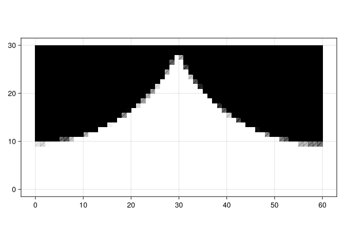

Figure 1: Heat sink optimization: conduction paths from top flux to left/right temperature fins

```julia
using CairoMakie
fig = visualize(problem; topology=result.minimizer)
```